# Simulating study design effect on diagnostic models

- Compare cross-sectional (CS) vs case-control (CC) designs for diagnostic model development and validation (internal and external)

# Load packages

```r
library(tidyverse)
library(ggpubr)
library(patchwork)
library(rms)
library(rmda)
theme_set(theme_bw())
source("R/functions.R")  # load helper functions
```

# Simulating the population

- population of 1M individuals.
- for each individual, we simulate continuous traits (eg blood biomarkers) using multivariate normal distribution, fix a set of (logistic) regression coefficients, and then use their linear combination to define the their true underlying probability of a binary outcome (e.g. having cancer).
- given the true probabilities, we then simulate the outcome itself.

```r
SEED <- 123456
n_pop <- 1e6
X <- get_X(
  n = n_pop,
  v = 2,                  # common variance
  corr = c(-0.2, 0, 0),   # correlations x1-x2, x1-x3, x2-x3
  mu = c(0, 0, 0),        # all centered
  .seed = SEED
)

beta <- c(-1.6, log(1.2), log(.3), log(3))
p <- plogis(X %*% beta)
y <- rbinom(n = n_pop, size = 1, prob = p)
df_pop <- data.frame(
  patient_id = paste0("patient-", 1:n_pop),
  y = y,
  p = p,
  x1 = X[, 2],
  x2 = X[, 3],
  x3 = X[, 4]
)
head(df_pop)
```

```
##   patient_id y           p         x1         x2         x3
## 1  patient-1 1 0.569076442 -0.7526996  1.0739182  3.0113315
## 2  patient-2 0 0.028950911  1.2866018  0.6818114 -1.2074034
## 3  patient-3 1 0.833946085 -0.1814995 -0.9592696  1.9042323
## 4  patient-4 0 0.123629566 -0.1494707  0.0422046 -0.2552622
## 5  patient-5 0 0.005517657 -1.3382222  3.5962228  0.8915541
## 6  patient-6 0 0.026553208 -0.6837702  1.1444403 -0.4543473
```

Prevalence of disease (or the average underlying probability) is about 30%.

```r
df_pop %>%
  summarise(mean(y), mean(p))
```

```
##    mean(y)  mean(p)
## 1 0.292072 0.292702
```

```r
group_differences(df_pop)
```

```
## # A tibble: 1 × 3
##   x1_diff x2_diff x3_diff
##     <dbl>   <dbl>   <dbl>
## 1   0.477   -1.41    1.24
```

- distribution of disease probabilities.
- maximum possible discrimination in this setting (how well the cases and controls are separated by their corresponding disease probabilities)

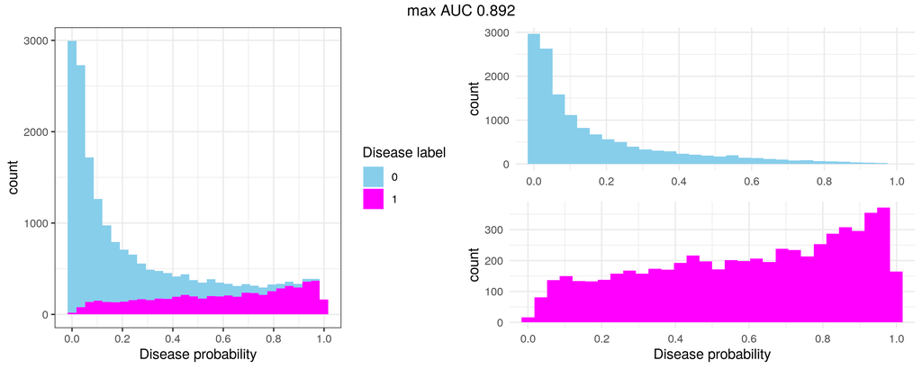

```r
.title <- paste0(
  "max AUC ", get_auc(df_pop$y, df_pop$p)
)
plot_disease_prob(df_pop[sample(1:n_pop, 2e4),], title = .title)
```

# Simulating a cross-section sample

- large sample size of `n_sample = 10000` such that we don’t suffer much from sampling variability.

```r
n_sample <- 1e4
df_sample_cs <- sample_cross_sectional(df = df_pop, n = n_sample)
```

The function `sample_cross_sectional` just takes an uniformly random sample from `df` of size `n`, such that the result (`df_sample_cs`) is representative of the overall population.

```r
.title <- paste0(
  "estimated AUC ", get_auc(df_sample_cs$y, df_sample_cs$p)
)
```

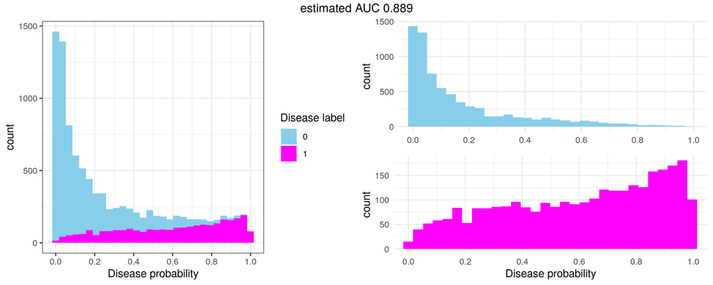

```r
plot_disease_prob(df = df_sample_cs, title = .title)
```

# Simulating a case-control sample

```r
cc_cutoffs <- c(0.3, 0.7)
df_sample_cc <- sample_case_control(df = df_pop, n = n_sample,
                                    cutoffs = cc_cutoffs)
.title <- paste0(
  "estimated AUC ", get_auc(df_sample_cc$y, df_sample_cc$p)
)
```

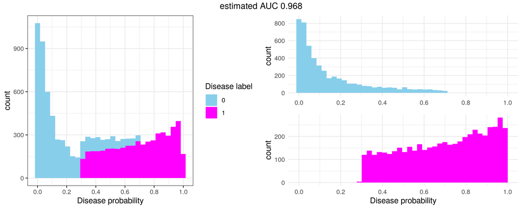

```r
plot_disease_prob(df = df_sample_cc, title = .title)
```

In the function `sample_case_control`, we take all cases, exclude those with probability of disease less than 30%, and then sample randomly from the ones left. We do it similarly for controls with probability of disease no larger than 70%. The rationale for this is to simulate the situation where you have a random sample from a setting (e.g. a hospital), but those patients at the hospital never go below 30% chance of disease - everyone is fairly clearly sick.

# Modeling

Now that we have two large samples from our population, one following a cross-sectional design (`df_sample_cs`) and another following a case-control design (`df_sample_cc`), we can estimate logistic regression models using each of them.

## Fitting and internal validation

### Cross-sectional data

We first fit and perform internal validation with the cross-sectional sample.

```r
fit_cs <- lrm(y ~ x1 + x2 + x3, data = df_sample_cs, x = TRUE, y = TRUE)
auc_cs <- get_auc_from_fit(fit_cs)
cat("\nEstimated coeffs: ", exp(coef(fit_cs)[-1]),
    "\nEstimated AUC (internal validation): ", auc_cs)
```

```
##
## Estimated coeffs:  1.190205 0.3043445 2.981205
## Estimated AUC (internal validation):  0.8888922
```

Notice that our estimated coefficients match almost perfectly the true values used to generate the data. Accordingly, the AUC is close to the maximum value for this population. The cross-sectional sample is representative and large enough to yield a nearly perfect model.

### Case-control data

```r
p_hat <- mean(df_sample_cs$y)
df_sample_cc$.offset <- get_prior_modeling_offset(p_hat = p_hat,
                                                  sampling_ratio = 0.5/0.5)
fit_cc <- lrm(y ~ x1 + x2 + x3, data = df_sample_cc, x = TRUE, y = TRUE)
auc_cc <- get_auc_from_fit(fit_cc)
cat("\nEstimated coeffs: ", exp(coef(fit_cc)[-1]),
    "\nEstimated AUC  (internal validation): ", auc_cc)
```

```
##
## Estimated coeffs:  1.514127 0.0576874 13.52023
## Estimated AUC  (internal validation):  0.9675967
```

- estimated coefficients too extreme (even though this is a very large sample n = 10000).
- estimated AUC from the internal validation is way too optimistic

## External validation

- two independent samples from the population, one with each design, excluding patients that where used for model fitting.

```r
development_patients <- c(
  df_sample_cs$patient_id,
  df_sample_cc$patient_id
)
n_val <- 20000
df_val_cs <- sample_cross_sectional(
  df = df_pop %>%
    filter(!(patient_id %in% development_patients)),
  n = n_val
)
df_val_cc <- sample_case_control(
  df = df_pop %>%
    filter(!(patient_id %in% development_patients)),
  n = n_val,
  cutoffs = cc_cutoffs
)
```

### Case-control validation data

Let’s see how the models perform in terms of discrimination.

```r
newdata <- df_val_cc
p_hat_cs <- predict(fit_cs, newdata = newdata, type = "fitted")
p_hat_cc <- predict(fit_cc, newdata = newdata, type = "fitted")
auc_cs <- get_auc(newdata$y, p_hat_cs)
auc_cc <- get_auc(newdata$y, p_hat_cc)
cat(
  "Estimated AUC (Case-control external validation):\nCross-sectional training: ", auc_cs,
  "\nCase-control training:", auc_cc
)
```

```
## Estimated AUC (Case-control external validation):
## Cross-sectional training:  0.97
## Case-control training: 0.97
```

- Case-control external validation overestimated discrimination
- Both training design types yielded the same estimated discrimination

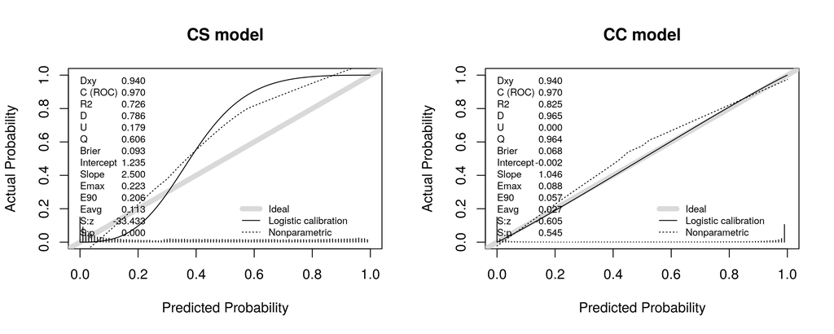

```r
par(mfrow = c(1, 2))
cal_cs <- val.prob(y = newdata$y, p = p_hat_cs)
title(main = 'CS model')
cal_cc <- val.prob(y = newdata$y, p = p_hat_cc)
title(main = 'CC model')
```

### Cross-sectional validation data

Let’s see how the models perform in terms of discrimination.

```r
newdata <- df_val_cs
p_hat_cs <- predict(fit_cs, newdata = newdata, type = "fitted")
p_hat_cc <- predict(fit_cc, newdata = newdata, type = "fitted")
auc_cs <- get_auc(newdata$y, p_hat_cs)
auc_cc <- get_auc(newdata$y, p_hat_cc)
cat(
  "Estimated AUC (Cross-sectional validation):\nCross-sectional training: ", auc_cs,
  "\nCase-control training:", auc_cc
)
```

```
## Estimated AUC (Cross-sectional validation):
## Cross-sectional training:  0.891
## Case-control training: 0.891
```

- both models perform equally well in terms of discrimination.
- estimated discrimination makes sense (respects maximum possible)

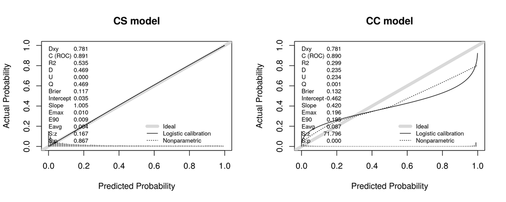

```r
par(mfrow = c(1, 2))
cal_cs <- val.prob(y = newdata$y, p = p_hat_cs)
title(main = 'CS model')
cal_cc <- val.prob(y = newdata$y, p = p_hat_cc)
title(main = 'CC model')
```

- CS model is well-calibrated
- CC model shows massive *overfitting*: predicted probabilities are too extreme - liekly due to overestimated coefficients.

We know this second calibration plot is representative of the *true calibration* - check with the true disease probabilities used to generate the data:

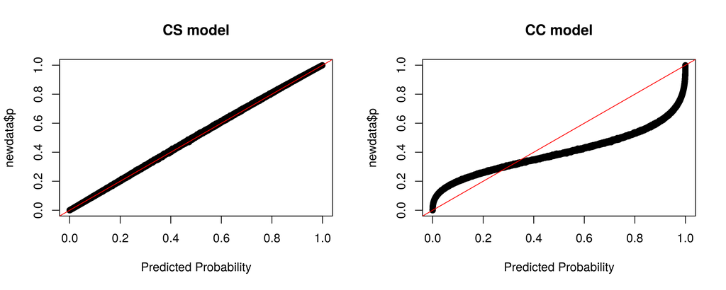

```r
par(mfrow = c(1, 2))
plot(p_hat_cs, newdata$p, main = "CS model", xlab = "Predicted Probability")
abline(0, 1, col = "red")
plot(p_hat_cc, newdata$p, main = "CC model", xlab = "Predicted Probability")
abline(0, 1, col = "red")
```

# Is it OK to use the CC model?

Let’s assess the consequences of model-based decisions.

## Decision curve analysis

```
## Note: When multiple decision curves are plotted, decision curves for 'All' are calculated using the prevalence from the first DecisionCurve object in the list provided.
```

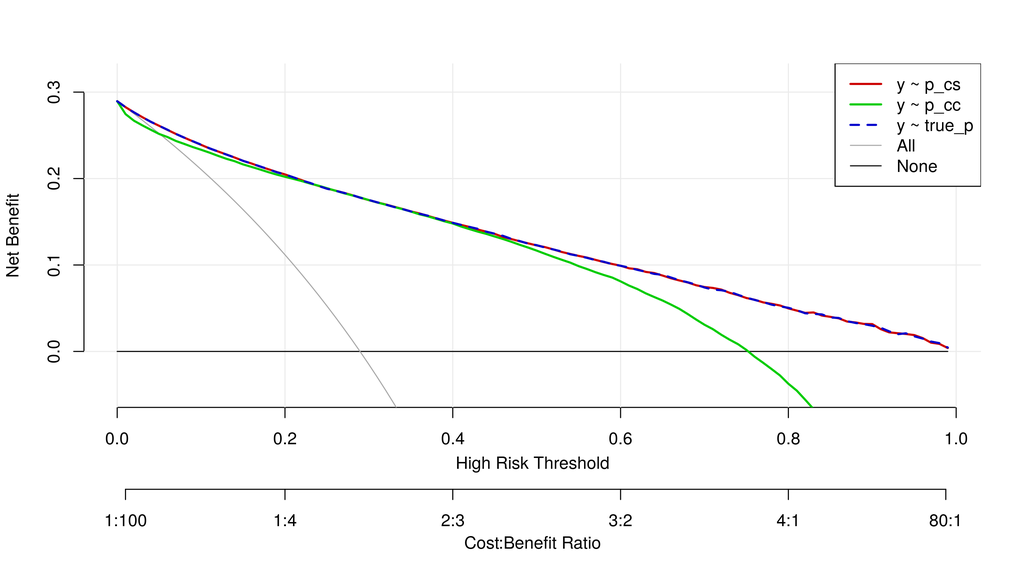

```r
dca_data <- data.frame(
  y = newdata$y,
  true_p = newdata$p,
  p_cc = p_hat_cc,
  p_cs = p_hat_cs
)
thresholds <- seq(0, .99, by = 0.01)
dca_cc <- decision_curve(y ~ p_cc, data = dca_data,
                         thresholds = thresholds,
                         bootstraps = 1,
                         fitted.risk = T)
dca_cs <- decision_curve(y ~ p_cs, data = dca_data,
                         thresholds = thresholds,
                         bootstraps = 1,
                         fitted.risk = T)
dca_true <- decision_curve(y ~ true_p, data = dca_data,
                           thresholds = thresholds,
                           bootstraps = 1,
                         fitted.risk = T)
par(mfrow = c(1, 1))
plot_decision_curve(
  list(dca_cs, dca_cc, dca_true),
  standardize = F,
  confidence.intervals = F,
  lty = c(1,1, 2)
)
```

## Undertreatment due to miscalibration

- At the time of intervention, we don’t have the labels y: our decisions are made based on the likelihood of the outcome
- The Negative Predictive Value (NPV) gives $\Pr(Y=0 \ | \textrm{ test -})$.
- Here, that translates to $\Pr(Y=0 \ | \hat{ p} < t)$.
- However, conditional on $ < t$, each individual still has their unique probability of disease $\implies \Pr(Y=0 \ | \hat{ p} < t)$ has a distribution.
- Under a NPV of 90%, you may have individuals with much more or much less than 90% probability of disease.
- If you are worried about undertreatment, it means you want lower thresholds.
- If your threshold is 10%, you wan to “send home” only people with less than 10% disease probability

### What is the NPV when predictive information is continuous

Say we have a discrete set of predicted probabilities $\hat{p_i}$ and corresponding outcomes $Y_i$ for individuals $i=1,2,\cdots, n$. An individual tests negative when its predicted probability is less than a threshold probability $t$. Them, the negative predictive value, defined as the probability of not having the disease when testing negative, is:

$$\begin{align}
\Pr(Y_i=0 | \textrm{model says "no disease"}) &= \Pr(Y_i=0 | \hat{p_i} < t) &\textrm{(Definition of NPV)}\\
&= \frac{
\Pr(Y_i = 0) \Pr(\hat{p_i} < t | Y_i = 0)
}{
\Pr(\hat{p_i} < t)
} &\textrm{(Bayes Theorem)} \\
&= \frac{
\Pr(Y_i = 0) \sum_{j<t}\Pr(\hat{p_i} = j | Y_i = 0)
}{
\sum_{j<t} \Pr(\hat{p_i} = j)
} &\textrm{(discrete probs.)} \\
&=(1-\textrm{Prevalence}) \frac{
\sum_{j<t}\Pr(\hat{p_i} = j | Y_i = 0)
}{
\sum_{j<t} \Pr(\hat{p_i} = j)
} &\textrm{(Prevalence definition)}
\end{align}$$

So the NPV for a predictive model depends on both the prevalence of the disease and the distribution of the predicted probabilities - marginal and conditional on being healthy.

> Not sure how to interpret this. But the NPV is hiding a series of individual probabilities.

### Undertreatment with CC model

```r
threshold <- 0.1
df_undertreat <- dca_data %>%
  filter(p_cc < threshold) %>%
  summarise(
    npv = mean(y == 0),
    undertreat = mean(true_p > threshold),
    medical_mistake = mean(true_p > threshold & y == 1)
  )

cat(
  "\nNPV :", df_undertreat$npv,
  "\nPeople sent home with more than 10% probability: ", df_undertreat$undertreat,
  "\nPeople who should be treated, were not treated, and indeed had the disease: ",
  df_undertreat$medical_mistake
)
```

```
##
## NPV : 0.9381625
## People sent home with more than 10% probability:  0.2522782
## People who should be treated, were not treated, and indeed had the disease:  0.03505672
```

#### Interpretation

> For every 1000 people sent home based on the CC model with a threshold of 10%, we expect about 252 to have a disease probability above 10% (undertreatment). Even though, on average, 938 out of those 1000 will not have the disease, those 252 people should be pretty upset - 35 of which in fact had the disease. This is because their actual disease probability was higher than what the model predicted. Those who didn’t have the disease in this group were “lucky”.

### Undertreatment with CS model

```r
df_undertreat <- dca_data %>%
  filter(p_cs < threshold) %>%
  summarise(
    npv = mean(y == 0),
    undertreat = mean(true_p > threshold),
    medical_mistake = mean(true_p > threshold & y == 1)
  )

cat(
  "\nNPV :", df_undertreat$npv,
  "\nPeople sent home with more than 10% probability: ", df_undertreat$undertreat,
  "\nPeople who should be treated, were not treated, and indeed had the disease: ",
  df_undertreat$medical_mistake
)
```

```
##
## NPV : 0.9634116
## People sent home with more than 10% probability:  0.006551298
## People who should be treated, were not treated, and indeed had the disease:  0.0009888752
```

## Overtreatment due to miscalibration

### Overtreatment CC model

```r
threshold <- 0.7
df_overtreat <- dca_data %>%
  filter(p_cc > threshold) %>%
  summarise(
    ppv = mean(y == 1),
    overtreat = mean(true_p < threshold)
  )

cat(
  "\nPPV :", df_overtreat$ppv,
  "\nProportion of people treated with less than 10% probability: ", df_overtreat$overtreat
)
```

```
##
## PPV : 0.7358053
## Proportion of people treated with less than 10% probability:  0.4335651
```

### Overtreatment with CS model

```r
df_overtreat <- dca_data %>%
  filter(p_cs > threshold) %>%
  summarise(
    ppv = mean(y == 1),
    overtreat = mean(true_p < threshold)
  )

cat(
  "\nPPV :", df_overtreat$ppv,
  "\nProportion of people treated with less than 10% probability: ", df_overtreat$overtreat
)
```

```
##
## PPV : 0.8581535
## Proportion of people treated with less than 10% probability:  0
```

# Under-/Over-treatment by threshold

```r
get_under_treatment <- function(data, phat, .threshold) {
  data <- data[data[[phat]] < .threshold, ]
  data %>%
    summarise(
      npv = mean(y == 1),
      undertreat = mean(true_p > .threshold),
      medical_mistake = mean(true_p > .threshold & y == 1)
    )
}

thresholds <- seq(0.01, 0.99, 0.01)
names(thresholds) <- thresholds

undertreat_cc <- map(thresholds, ~{
  dca_data %>%
    get_under_treatment("p_cc", .x) %>%
    mutate(model = "CC model")
}) %>%
  bind_rows(.id = "threshold") %>%
  mutate(threshold = as.numeric(threshold))

undertreat_cs <- map(thresholds, ~{
  dca_data %>%
    get_under_treatment("p_cs", .x) %>%
    mutate(model = "CS model")
}) %>%
  bind_rows(.id = "threshold") %>%
  mutate(threshold = as.numeric(threshold))

p1 <- ggplot() +
  geom_line(
    data = undertreat_cc,lwd = 1.5,
    aes(threshold, undertreat*1000, color = "CC model")
  ) +
  geom_line(
    data = undertreat_cs,lwd = 1.5,
    aes(threshold, undertreat*1000, color = "CS model")
  ) +
  labs(x = "threshold", y = "Undertreatment per 1000",
       subtitle = "Undertreated patients per 1000 persons sent home",
       color = NULL)
p1.2 <- ggplot() +
  geom_line(
    data = undertreat_cc,linetype=5,lwd = 1.5,
    aes(threshold, medical_mistake*1000, color = "CC model (Y=1)")
  ) +
  geom_line(
    data = undertreat_cs, linetype=5, lwd = 1.5,
    aes(threshold, medical_mistake*1000, color = "CS model (Y=1)")
  ) +
  labs(x = "threshold", y = "Undertreatment per 1000",
       subtitle = "Undertreated sick patients per 1000 persons sent home",
       color = NULL)
```

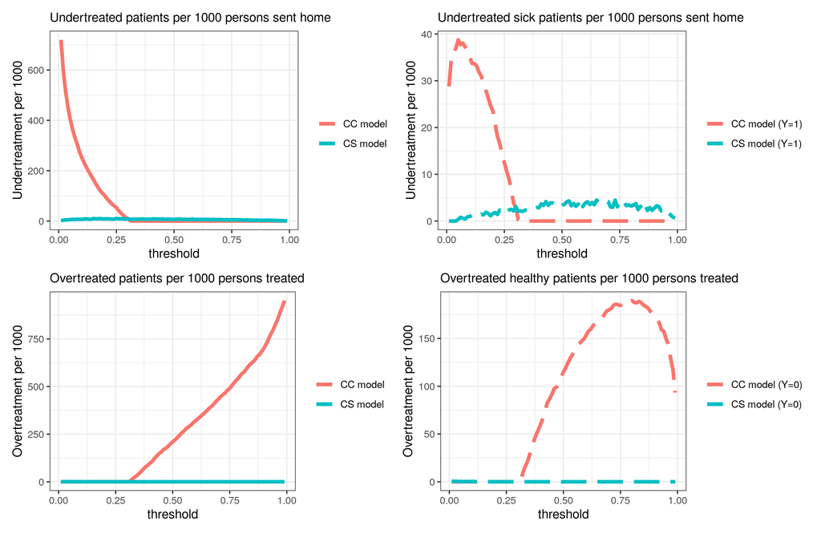

```r
get_over_treatment <- function(data, phat, .threshold) {
  data <- data[data[[phat]] > .threshold, ]
  data %>%
    summarise(
      npv = mean(y == 0),
      undertreat = mean(true_p < .threshold),
      medical_mistake = mean(true_p < .threshold & y == 0)
    )
}


overtreat_cc <- map(thresholds, ~{
  dca_data %>%
    get_over_treatment("p_cc", .x) %>%
    mutate(model = "CC model")
}) %>%
  bind_rows(.id = "threshold") %>%
  mutate(threshold = as.numeric(threshold))

overtreat_cs <- map(thresholds, ~{
  dca_data %>%
    get_over_treatment("p_cs", .x) %>%
    mutate(model = "CS model")
}) %>%
  bind_rows(.id = "threshold") %>%
  mutate(threshold = as.numeric(threshold))

p2 <- ggplot() +
  geom_line(
    data = overtreat_cc,lwd = 1.5,
    aes(threshold, undertreat*1000, color = "CC model")
  ) +
  geom_line(
    data = overtreat_cs,lwd = 1.5,
    aes(threshold, undertreat*1000, color = "CS model")
  ) +
  labs(x = "threshold", y = "Overtreatment per 1000",
       subtitle = "Overtreated patients per 1000 persons treated",
       color = NULL)

p2.2 <- ggplot() +
  geom_line(
    data = overtreat_cc,linetype=5,lwd = 1.5,
    aes(threshold, medical_mistake*1000, color = "CC model (Y=0)")
  ) +
  geom_line(
    data = overtreat_cs,linetype=5,lwd = 1.5,
    aes(threshold, medical_mistake*1000, color = "CS model (Y=0)")
  ) +
  labs(x = "threshold", y = "Overtreatment per 1000",
       subtitle = "Overtreated healthy patients per 1000 persons treated",
       color = NULL)

(p1 | p1.2) / (p2 | p2.2)
```

# Estimating under-/over-treatment

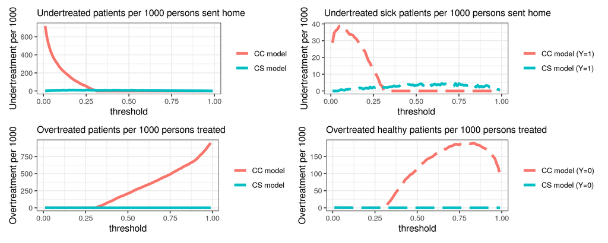

```r
undertreat_cc_hat <- map(thresholds, ~{
  dca_data %>%
    get_under_treatment("p_cc", .x) %>%
    mutate(model = "CC model")
}) %>%
  bind_rows(.id = "threshold") %>%
  mutate(threshold = as.numeric(threshold))

undertreat_cs <- map(thresholds, ~{
  dca_data %>%
    get_under_treatment("p_cs", .x) %>%
    mutate(model = "CS model")
}) %>%
  bind_rows(.id = "threshold") %>%
  mutate(threshold = as.numeric(threshold))

p1 <- ggplot() +
  geom_line(
    data = undertreat_cc,lwd = 1.5,
    aes(threshold, undertreat*1000, color = "CC model")
  ) +
  geom_line(
    data = undertreat_cs,lwd = 1.5,
    aes(threshold, undertreat*1000, color = "CS model")
  ) +
  labs(x = "threshold", y = "Undertreatment per 1000",
       subtitle = "Undertreated patients per 1000 persons sent home",
       color = NULL)
p1.2 <- ggplot() +
  geom_line(
    data = undertreat_cc,linetype=5,lwd = 1.5,
    aes(threshold, medical_mistake*1000, color = "CC model (Y=1)")
  ) +
  geom_line(
    data = undertreat_cs, linetype=5, lwd = 1.5,
    aes(threshold, medical_mistake*1000, color = "CS model (Y=1)")
  ) +
  labs(x = "threshold", y = "Undertreatment per 1000",
       subtitle = "Undertreated sick patients per 1000 persons sent home",
       color = NULL)

get_over_treatment <- function(data, phat, .threshold) {
  data <- data[data[[phat]] > .threshold, ]
  data %>%
    summarise(
      npv = mean(y == 0),
      undertreat = mean(true_p < .threshold),
      medical_mistake = mean(true_p < .threshold & y == 0)
    )
}


overtreat_cc <- map(thresholds, ~{
  dca_data %>%
    get_over_treatment("p_cc", .x) %>%
    mutate(model = "CC model")
}) %>%
  bind_rows(.id = "threshold") %>%
  mutate(threshold = as.numeric(threshold))

overtreat_cs <- map(thresholds, ~{
  dca_data %>%
    get_over_treatment("p_cs", .x) %>%
    mutate(model = "CS model")
}) %>%
  bind_rows(.id = "threshold") %>%
  mutate(threshold = as.numeric(threshold))

p2 <- ggplot() +
  geom_line(
    data = overtreat_cc,lwd = 1.5,
    aes(threshold, undertreat*1000, color = "CC model")
  ) +
  geom_line(
    data = overtreat_cs,lwd = 1.5,
    aes(threshold, undertreat*1000, color = "CS model")
  ) +
  labs(x = "threshold", y = "Overtreatment per 1000",
       subtitle = "Overtreated patients per 1000 persons treated",
       color = NULL)

p2.2 <- ggplot() +
  geom_line(
    data = overtreat_cc,linetype=5,lwd = 1.5,
    aes(threshold, medical_mistake*1000, color = "CC model (Y=0)")
  ) +
  geom_line(
    data = overtreat_cs,linetype=5,lwd = 1.5,
    aes(threshold, medical_mistake*1000, color = "CS model (Y=0)")
  ) +
  labs(x = "threshold", y = "Overtreatment per 1000",
       subtitle = "Overtreated healthy patients per 1000 persons treated",
       color = NULL)

(p1 | p1.2) / (p2 | p2.2)
```

# Updating the CC model with a CS sample

```r
previous_patients <- c(
  df_sample_cs$patient_id,
  df_sample_cc$patient_id,
  df_val_cc$patient_id,
  df_val_cs$patient_id
)
df_sample_cs_updating <- sample_cross_sectional(
  df = df_pop %>%
    filter(!(patient_id %in% previous_patients)),
  n = 2e5
)
df_cc_updating <- data.frame(
  y = df_sample_cs_updating$y,
  LP = predict(fit_cc, newdata = df_sample_cs_updating) - coef(fit_cc)[1]
)
fit_cc2 <- lrm(y ~ LP, data = df_cc_updating, x = TRUE, y = TRUE)
df_val <- data.frame(
  LP = predict(fit_cc, newdata = df_val_cs) - coef(fit_cc)[1],
  y = df_val_cs$y
)
p_hat_cc2 <- predict(fit_cc2, newdata = df_val, type = "fitted")
auc_cc2 <- get_auc(df_val$y, p_hat_cc2)
cat("\nAUC of updated CC model in external CS daya: ", auc_cc2)
```

```
##
## AUC of updated CC model in external CS daya:  0.891
```

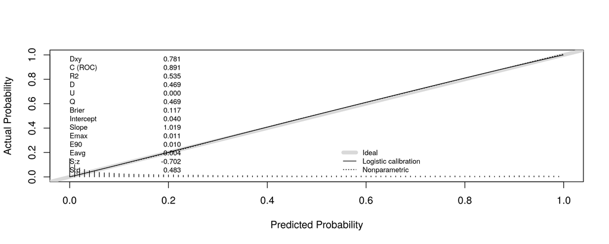

```
##           Dxy       C (ROC)            R2             D      D:Chi-sq
##  7.810871e-01  8.905435e-01  5.348984e-01  4.688720e-01  9.378441e+03
##           D:p             U      U:Chi-sq           U:p             Q
##            NA  7.315193e-05  3.463039e+00  1.770153e-01  4.687989e-01
##         Brier     Intercept         Slope          Emax           E90
##  1.167009e-01  3.970547e-02  1.018721e+00  1.066141e-02  9.756567e-03
##          Eavg           S:z           S:p
##  3.965312e-03 -7.018105e-01  4.827974e-01
```

```r
val.prob(p = p_hat_cc2, df_val$y)
```

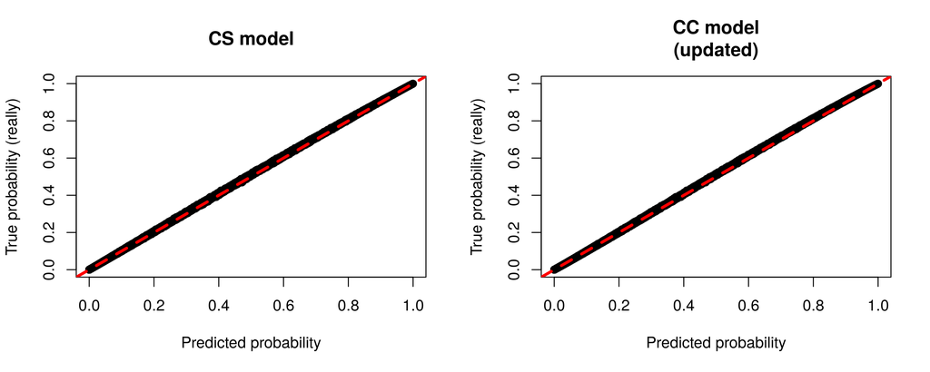

```r
par(mfrow = c(1, 2))
plot(
  predict(fit_cs, newdata = df_val_cs, type = "fitted"),
  df_val_cs$p,
  main = "CS model",
  xlab = "Predicted probability",
  ylab = "True probability (really)"
)
abline(0, 1, lwd = 3, col = "red", lty = 2)
plot(
  p_hat_cc2,
  df_val_cs$p,
  main = "CC model\n(updated)",
  xlab = "Predicted probability",
  ylab = "True probability (really)"
)
abline(0, 1, lwd = 3, col = "red", lty = 2)
```

# how cool is this?

```r
beta
```

```
## [1] -1.6000000  0.1823216 -1.2039728  1.0986123
```

```r
coef(fit_cs)
```

```
##  Intercept         x1         x2         x3
## -1.6237807  0.1741258 -1.1895951  1.0923274
```

```r
c( coef(fit_cc2)[1],   coef(fit_cc2)[2]*coef(fit_cc)[-1] )
```

```
##  Intercept         x1         x2         x3
## -1.6060943  0.1710938 -1.1765576  1.0740554
```

```r
coef(fit_cc)
```

```
##  Intercept         x1         x2         x3
## -2.7004249  0.4148391 -2.8527165  2.6041868
```

# another try on the consequences of cutoffs

## with true probabilities

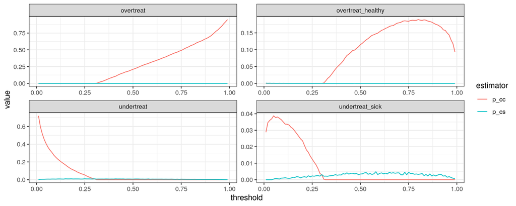

```r
df_val_cs$p_cc <- p_hat_cc
df_val_cs$p_cs <- p_hat_cs

consequences_cc <- get_decision_consequences(
  df_val_cs,
  phat = "p_cc",
  .thresholds = thresholds
)
consequences_cs <- get_decision_consequences(
  df_val_cs,
  phat = "p_cs",
  .thresholds = thresholds
)

bind_rows(consequences_cc,
          consequences_cs) %>%
  select(-contains('pv')) %>%
  pivot_longer(
    cols = -c(threshold, estimator)
  ) %>%
  ggplot(aes(threshold, value, color = estimator)) +
  geom_line() +
  facet_wrap(~name, scales = "free")
```

## with internal model

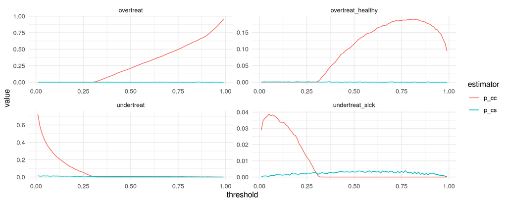

```r
df_val_cs$lp_cc <- predict(fit_cc, newdata = df_val_cs)
df_val_cs$lp_cs <- predict(fit_cs, newdata = df_val_cs)
fit_val_cc <- lrm(y ~ rcs(lp_cc, 5), data = df_val_cs, x = T, y = T)
fit_val_cs <- lrm(y ~ rcs(lp_cs, 5), data = df_val_cs, x = T, y = T)
fit_val <- lrm(y ~ x1 + x2 + x3, data = df_val_cs, x = T, y = T)

df_val_cs$p_tilde <- predict(fit_val, type = "fitted")
df_val_cs$p_tilde_cc <- predict(fit_val_cc, type = "fitted")
df_val_cs$p_tilde_cs <- predict(fit_val_cs, type = "fitted")


consequences_cc_hat <- get_decision_consequences(
  df_val_cs,
  phat = "p_cc",
  p = "p_tilde",
  .thresholds = thresholds
)
consequences_cs_hat <- get_decision_consequences(
  df_val_cs,
  phat = "p_cs",
  p = "p_tilde",
  .thresholds = thresholds
)

bind_rows(consequences_cc_hat,
          consequences_cs_hat) %>%
  select(-contains('pv')) %>%
  pivot_longer(
    cols = -c(threshold, estimator)
  ) %>%
  ggplot(aes(threshold, value, color = estimator)) +
  geom_line() +
  facet_wrap(~name, scales = "free") +
  theme_minimal()
```

# DCA with p_tilde

$$NB_t^{\prime} = \Pr(\hat{p} > t | \tilde{p} > t)\Pr(\tilde{p} > t)
- \textrm{odds}(t)\Pr(\hat{p} > t | \tilde{p} < t)\Pr(\tilde{p} < t)$$

$\tilde{p}$ comes from model fit in the external data.

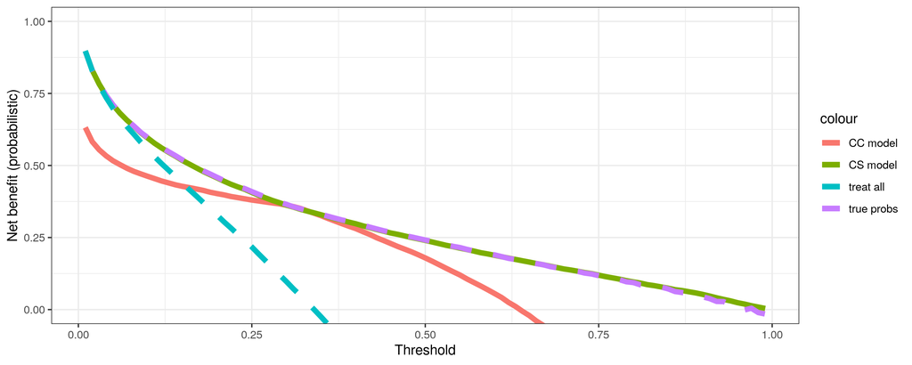

```r
map(thresholds, ~ {
  prev <- mean(df_val_cs$p_tilde > .x)
  se_cc <- mean(
    df_val_cs$p_cc[df_val_cs$p_tilde > .x] > .x
  )
  se_cs <- mean(
    df_val_cs$p_cs[df_val_cs$p_tilde > .x] > .x
  )
  sp_cc <- mean(
     df_val_cs$p_cc[df_val_cs$p_tilde < .x] < .x
  )
  sp_cs <- mean(
     df_val_cs$p_cs[df_val_cs$p_tilde < .x] < .x
  )
  # true values
  se <- mean(
    df_val_cs$p[df_val_cs$p_tilde > .x] > .x
  )
  sp <- mean(
     df_val_cs$p[df_val_cs$p_tilde < .x] < .x
  )
  data.frame(
    nb = se*prev - odds(.x)*(1-sp)*(1-prev),
    nb_cc = se_cc*prev - odds(.x)*(1-sp_cc)*(1-prev),
    nb_cs = se_cs*prev - odds(.x)*(1-sp_cs)*(1-prev),
    thr = .x,
    treat_all = 1*prev - odds(.x)*(1-0)*(1-prev)
  )
}) %>%
  bind_rows() %>%
  ggplot(aes(thr)) +
  geom_line(aes(y = nb_cc, color = "CC model"), lwd = 2) +
  geom_line(aes(y = nb_cs, color = "CS model"), lwd = 2) +
  geom_line(aes(y = nb, color = "true probs"), lwd = 2, lty = 2) +
  geom_line(aes(y = treat_all, color = "treat all"), lwd = 2, lty = 2) +
  coord_cartesian(ylim = c(0, 1)) +
  labs(x = "Threshold", y = "Net benefit (probabilistic)")
```

# traditional dca

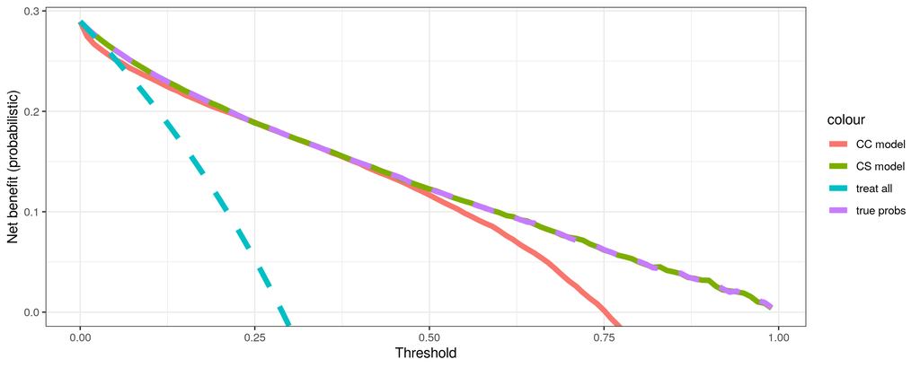

```r
map(c(0,thresholds), ~ {
  prev <- mean(df_val_cs$y == 1)
  se_cc <- mean(
    df_val_cs$p_cc[df_val_cs$y == 1] > .x
  )
  se_cs <- mean(
    df_val_cs$p_cs[df_val_cs$y == 1] > .x
  )
  sp_cc <- mean(
     df_val_cs$p_cc[df_val_cs$y == 0] < .x
  )
  sp_cs <- mean(
     df_val_cs$p_cs[df_val_cs$y == 0] < .x
  )
  # true values
  se <- mean(
    df_val_cs$p[df_val_cs$y == 1] > .x
  )
  sp <- mean(
     df_val_cs$p[df_val_cs$y == 0] < .x
  )
  data.frame(
    nb = se*prev - odds(.x)*(1-sp)*(1-prev),
    nb_cc = se_cc*prev - odds(.x)*(1-sp_cc)*(1-prev),
    nb_cs = se_cs*prev - odds(.x)*(1-sp_cs)*(1-prev),
    thr = .x,
    treat_all = 1*prev - odds(.x)*(1-0)*(1-prev)
  )
}) %>%
  bind_rows() %>%
  ggplot(aes(thr)) +
  geom_line(aes(y = nb_cc, color = "CC model"), lwd = 2) +
  geom_line(aes(y = nb_cs, color = "CS model"), lwd = 2) +
  geom_line(aes(y = nb, color = "true probs"), lwd = 2, lty = 2) +
  geom_line(aes(y = treat_all, color = "treat all"), lwd = 2, lty = 2) +
  coord_cartesian(ylim = c(0, NA)) +
  labs(x = "Threshold", y = "Net benefit (probabilistic)")
```

# DCA with p_tilde_cc and p_tilde_cs

[figure not shown]

```r
map(thresholds, ~ {
  prev <- mean(df_val_cs$p_tilde > .x)
  prev_cc <- mean(df_val_cs$p_tilde_cc > .x)
  prev_cs <- mean(df_val_cs$p_tilde_cs > .x)
  se_cc <- mean(
    df_val_cs$p_cc[df_val_cs$p_tilde_cc > .x] > .x
  )
  se_cs <- mean(
    df_val_cs$p_cs[df_val_cs$p_tilde_cs > .x] > .x
  )
  sp_cc <- mean(
     df_val_cs$p_cc[df_val_cs$p_tilde_cc < .x] < .x
  )
  sp_cs <- mean(
     df_val_cs$p_cs[df_val_cs$p_tilde_cs < .x] < .x
  )
  # true values
  se <- mean(
    df_val_cs$p[df_val_cs$p_tilde > .x] > .x
  )
  sp <- mean(
     df_val_cs$p[df_val_cs$p_tilde < .x] < .x
  )
  data.frame(
    nb = se*prev - odds(.x)*(1-sp)*(1-prev),
    nb_cc = se_cc*prev_cc - odds(.x)*(1-sp_cc)*(1-prev_cc),
    nb_cs = se_cs*prev_cs - odds(.x)*(1-sp_cs)*(1-prev_cs),
    thr = .x,
    treat_all = 1*prev - odds(.x)*(1-0)*(1-prev)
  )
}) %>%
  bind_rows() %>%
  ggplot(aes(thr)) +
  geom_line(aes(y = nb_cc, color = "CC model"), lwd = 2) +
  geom_line(aes(y = nb_cs, color = "CS model"), lwd = 2) +
  geom_line(aes(y = nb, color = "true probs"), lwd = 2, lty = 2) +
  geom_line(aes(y = treat_all, color = "treat all"), lwd = 2, lty = 2) +
  coord_cartesian(ylim = c(0, 1)) +
  labs(x = "Threshold", y = "Net benefit (probabilistic)")
```